# Avaliação de Estatística e Experimentação: 1° Parte

Márlon de Castro Vasconcelos

24 Novembro, 2021

# 1 Uma introdução

Avaliar conjuntos de dados nunca é *fácil*. O mais importante é saber o contexto no qual os dados foram obtidos, seu desenho experimental, os objetivos pretendidos e as hipóteses testadas.

Ainda que não tenhamos todas as informações há algumas formas de tentarmos minimizar esse *escuro*. Uma delas são identificar os tipos de variáveis, quais são **fatores** e quais são **númericas**. Depois, tentar identificar quais podem ser possíveis variáveis **respostas** e **explicações**. Assim, podemos produzir gráficos para entender o contexto do que está acontecendo.

# 2 Dados

Nessa atividade avaliativa foram deixados três bancos de dados para que fossem devidamente avaliados. O primeiro é o conjunto CO<sub>2</sub>, o segundo Orange e por fim ChickWeigh.

Para cada um deles deveria:

```
1. Estatistica descritiva para cada base de dados
2. Para cada base de dados:
   a. O discente deverá escolher variáveis para realizar análises        estatísticas pertinentes às escolhas feitas.
        a.1. Identificar o tipo de variável
        a.2. Qual é resposta e qual explicativa
   b. Comentar em cada passo as decisões tomadas.
```

## 2.1 Banco CO<sub>2</sub>.

Esse conjunto de dados avalia a resistência ao frio em uma espécie de gramínea (*Echinochloa crusgalli*) tendo como fatores de estudo: O local onde a planta se oprigina (Type); Identificação de cada “indivíduo” (Plant); Tratamento com quelante (Treatment); Concentração ambiental de CO<sub>2</sub> em ml.L (conc) e por fim uma variável que mensura o “resultado” do experimento (uptake) em umol/m<sup>2</sup>.sec)

Para maiores informações sobre o conjunto de dados pode ser obtido usando `help(CO2)`, ou no artigo [Artigo oringial](https://www.jstor.org/stable/1938276).

## 2.2 Banco Orange.

Esse conjunto de dados avalia o efeito da idade (age) sobre a circunferência (circumference) de árvores de Laranja (Tree). Assim a variável idade em sete momentos. A variável árvore, identifica o indivíduo que está sendo monitorado para aquele valor de idade e circunferência.

Para maiores informações sobre o conjunto de dados pode ser obtido usando `help(Orange)`.

## 2.3 Banco ChickWeight .

Esse conjunto de dados avalia O efeito da dieta (Diet), sobre o ganho precosse de peso (weight) em frangos (Chick) e a variável tempo (Time) avalia o tempo desde o nascimento até a mensuração do peso. Assim, temos que a variável frango controla as mensurações para cada indivíduo.

Para maiores informações sobre o conjunto de dados pode ser obtido usando `help(ChickWeight)`.

## 2.4 Carregando os bancos de dados

Esses bancos de dados já se encontram nativos no R. Desta forma, para carregalos basta digitar seu nome no **console** ou por meio do **script** usando a função `data()`, onde dentro do () irá o nome do conjunto desejado.

```
# exemplo:
Orange
# Ou
data(Orange)
```

# 3 Começando a analisar os dados

Para começar a analisar quaisquer conjuntos de dadoss é importante conhecer os dados. Saber como foram obtidos, qual o seu desenho experimental, se em DBC, DIC, DQL se são aninhados, isto é, se há uma hierarquia nos fatores de estudo. Isso é importante para saber qual a análise ou modelo mais adequado para avaliar os objetivos e hipóteses pretendidos em cada conjunto de dados.

Começarei pela ordem com que os dados foram apresentados aqui.

## 3.1 CO<sub>2</sub>.

```r
data(CO2)
# Perceba que as letras estão em Maíusculo no mome do conjunto de dados

# # Renomeando a variável Type para Origem
CO2 <- CO2 |> rename(Origem = Type)

glimpse(CO2)
```

```
## Rows: 84
## Columns: 5
## $ Plant     <ord> Qn1, Qn1, Qn1, Qn1, Qn1, Qn1, Qn1, Qn2, Qn2, Qn2, Qn2, Qn2, …
## $ Origem    <fct> Quebec, Quebec, Quebec, Quebec, Quebec, Quebec, Quebec, Queb…
## $ Treatment <fct> nonchilled, nonchilled, nonchilled, nonchilled, nonchilled, …
## $ conc      <dbl> 95, 175, 250, 350, 500, 675, 1000, 95, 175, 250, 350, 500, 6…
## $ uptake    <dbl> 16.0, 30.4, 34.8, 37.2, 35.3, 39.2, 39.7, 13.6, 27.3, 37.1, …
```

Percebemos que as variáveis Type e Treatment, são fatores; conc e uptake são variáveis do tipo duplo (numéricas) e Plant é uma variável ordinal. Essa variável precisa ser transformada em fator para podermos usa-la no contexto das análsies mostradas durante a disciplina. Isso se deve, para podermos usar essa variável como uma variação intrasujeito (within), isto é, os tratamentos, levam em consideração o indivíduo ao longo do tempo para avaliar o efeito entre sujeitos (between) que a variável Treatment.

No caso desse conjunto de dados temos que realizar uma ANOVA de dois fatores. Tendo como variáveis explicativas, Tratamento e a Origem da Planta.

```r
# Vamos criar uma tabela para visualizar os dados.
kable(head(CO2, # Conjunto
  10), # Aparecer as 10 primeiras linhas
  col.names = c("Planta", "Origem", "Tratamento", "Conc. CO~2~", "Uptake") # Nomear as colunas
  ) |>
kable_styling(full_width = F, bootstrap_options = c("striped", "hover", "condensed", "responsive")
) # Aqui para dar essa "carinha" para a tabela
```

| Planta | Origem | Tratamento | Conc. CO<sub>2</sub> | Uptake |
| --- | --- | --- | --- | --- |
| Qn1 | Quebec | nonchilled | 95 | 16.0 |
| Qn1 | Quebec | nonchilled | 175 | 30.4 |
| Qn1 | Quebec | nonchilled | 250 | 34.8 |
| Qn1 | Quebec | nonchilled | 350 | 37.2 |
| Qn1 | Quebec | nonchilled | 500 | 35.3 |
| Qn1 | Quebec | nonchilled | 675 | 39.2 |
| Qn1 | Quebec | nonchilled | 1000 | 39.7 |
| Qn2 | Quebec | nonchilled | 95 | 13.6 |
| Qn2 | Quebec | nonchilled | 175 | 27.3 |
| Qn2 | Quebec | nonchilled | 250 | 37.1 |

### 3.1.1 Distribuição da variável Resposta

Histograma e Estatistica Descritiva

#### 3.1.1.1 Geral

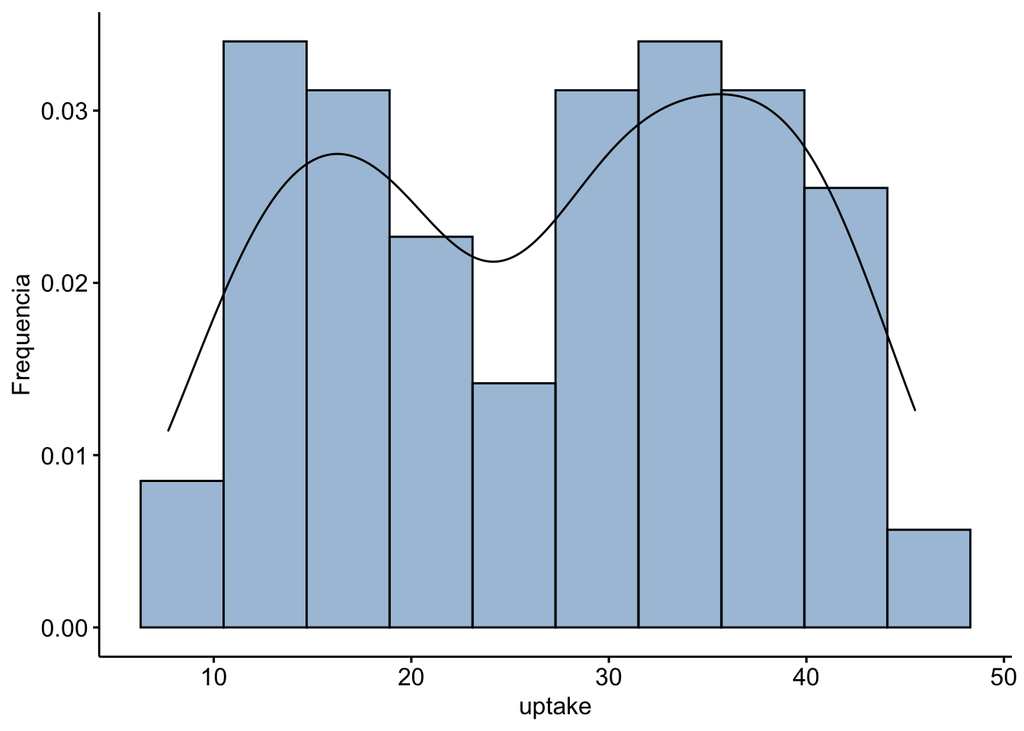

#### 3.1.1.2 Por nível de Tratamento

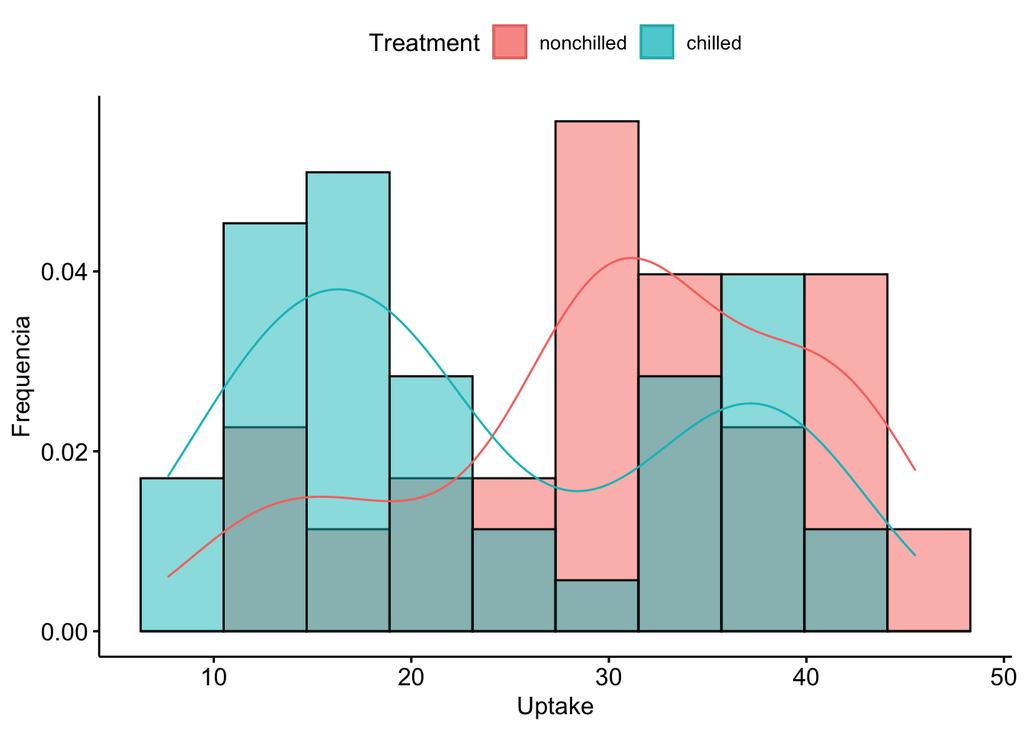

#### 3.1.1.3 Por nível Origem.

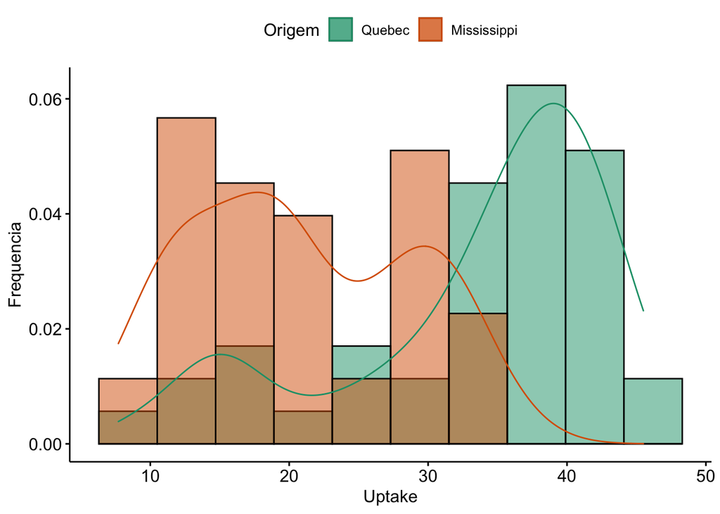

#### 3.1.1.4 Estatística Descritiva

| Origem | Treatment | variable | n | min | max | median | iqr | mean | sd | se | ci |
| --- | --- | --- | --- | --- | --- | --- | --- | --- | --- | --- | --- |
| Quebec | nonchilled | uptake | 21 | 13.6 | 45.5 | 39.2 | 9.4 | 35.333 | 9.596 | 2.094 | 4.368 |
| Mississippi | nonchilled | uptake | 21 | 10.6 | 35.5 | 28.1 | 9.1 | 25.952 | 7.402 | 1.615 | 3.369 |
| Quebec | chilled | uptake | 21 | 9.3 | 42.4 | 35.0 | 11.4 | 31.752 | 9.645 | 2.105 | 4.390 |
| Mississippi | chilled | uptake | 21 | 7.7 | 22.2 | 17.9 | 6.4 | 15.814 | 4.059 | 0.886 | 1.848 |

Vemos pelo hitograma que a distribuição não normal. Temos dois picos, pode ser por causa nas diferenças entre os tratamentos como e sem quelante.

### 3.1.2 Verificação dos pressupostos do modelo

#### 3.1.2.1 Normalidade

A variável dependente (“uptake”) deve apresentar distribuição aproximadamente normal dentro de cada nível da variável Tratamento. A normalidade será avaliada pelo teste de Shapiro-Wilk.

```r
shapiro.co2 <- CO2 %>% group_by(Treatment, Origem) %>% shapiro_test(uptake)
```

```r
kable(head(shapiro.co2)) |>
kable_styling(full_width = F)
```

| Origem | Treatment | variable | statistic | p |
| --- | --- | --- | --- | --- |
| Quebec | nonchilled | uptake | 0.8252592 | 0.0016391 |
| Mississippi | nonchilled | uptake | 0.8551907 | 0.0052258 |
| Quebec | chilled | uptake | 0.8529291 | 0.0047730 |
| Mississippi | chilled | uptake | 0.9481933 | 0.3147414 |

Aqui, podemos transformar a variável uptaque por `log1p` ou `sqrt()`. Isso é uma forma de que os dados possam possuir distribuição normal. Outra abordagem é o uso de modelos que não seguem os pressupostos dos testes paramétricos como os Modelos Lineares Generalisados - GLM. Neles podemos indicar a distribuição dos dados. Contudo, para fins *didáticos* proceguirei como se os nossos dados tivessem distribuição normal

#### 3.1.2.2 Ausência de *outliers*

Outro pressuposto da ANOVA é a ausência de *outliers* em todos os grupos. Isso pode ser verificado através de um gráfico do tipo boxplot.

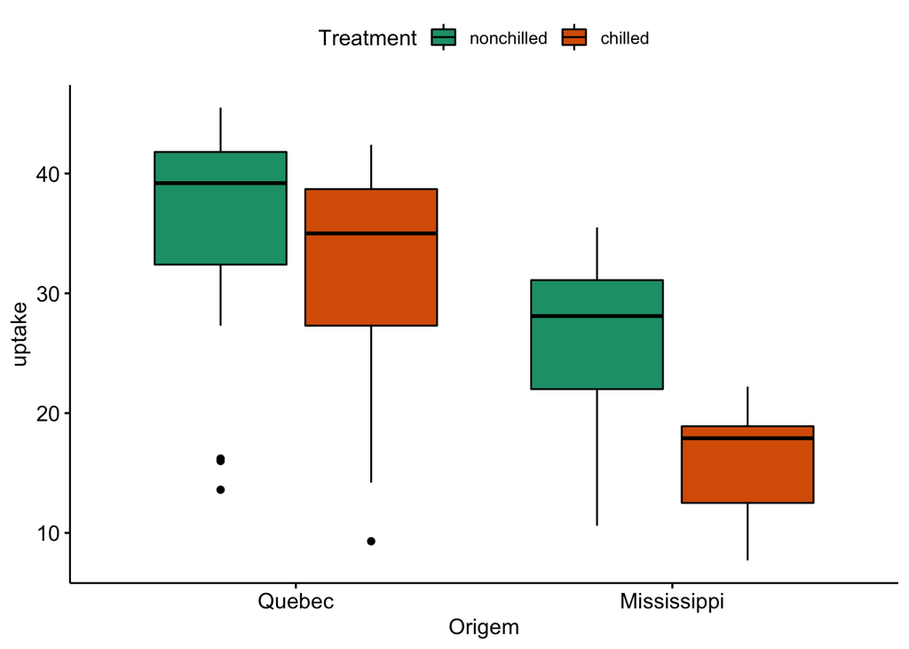

```r
ggboxplot(CO2, x = "Origem", y = "uptake", fill = "Treatment",
          palette = "Dark2"
          )
```

Os gráficos mostram que possuímos *outliers* nos grupos analisados. Esses ouliers são os pontos abaixo dos boxplots.

### 3.1.3 Homogeneidade de variâncias

Outro pressuposto da ANOVA é que os grupos apresentem variâncias homogêneas. Esse pressuposto será analisado aqui pelo teste de Levene.

#### 3.1.3.1 Tratamento

```r
levene.co2.trat <- CO2 |> levene_test(uptake ~ Treatment)
```

| df1 | df2 | statistic | p |
| --- | --- | --- | --- |
| 1 | 82 | 1.299853 | 0.2575593 |

#### 3.1.3.2 Origem

```r
levene.co2.origem <- CO2 |> levene_test(uptake ~ Origem)
```

| df1 | df2 | statistic | p |
| --- | --- | --- | --- |
| 1 | 82 | 0.1704399 | 0.6807986 |

Os resultados indicam que as variâncias são homogêneas, uma vez que o teste de Levene apresentou P > 0,05.

### 3.1.4 Criação do modelo de ANOVA de dois fatores

Usaremos a função `anova_test()` do pacote `rstatix`.

```r
resu.co2 <- CO2|> anova_test(uptake ~ Treatment*Origem,
                 type = 3) # Forma de calculo, desconsidera a ordem de entrada dos dados
```

```
## Coefficient covariances computed by hccm()
```

```r
# Modelo usando transformação anova_test(log1p(uptake) ~ Treatment*Origem, type = 3
```

### 3.1.5 Análise dos resultados do modelo

O resultado nos indica que não há efeito da interação entre o Tratamento com Quelante e a Origem da Planta [F(1,80) = 3.522; p = 0.064]. Assim olharemos os fatores em separado como um teste t.

#### 3.1.5.1 Tratamento

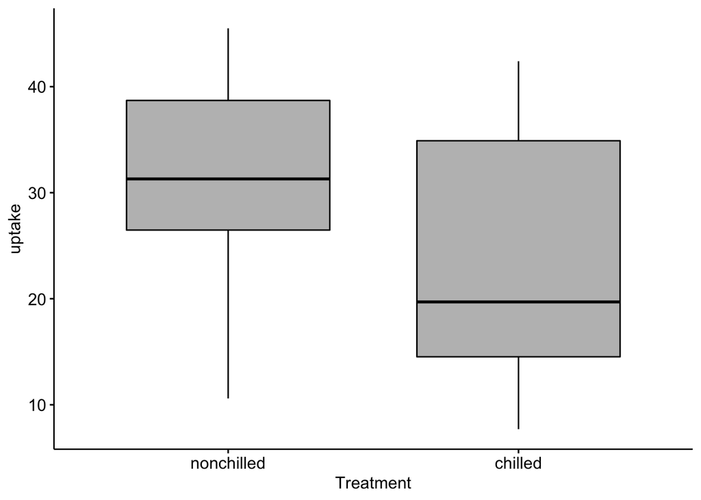

```r
ggboxplot(CO2, x = "Treatment", y = "uptake", fill = "Gray")
```

#### 3.1.5.2 Origem

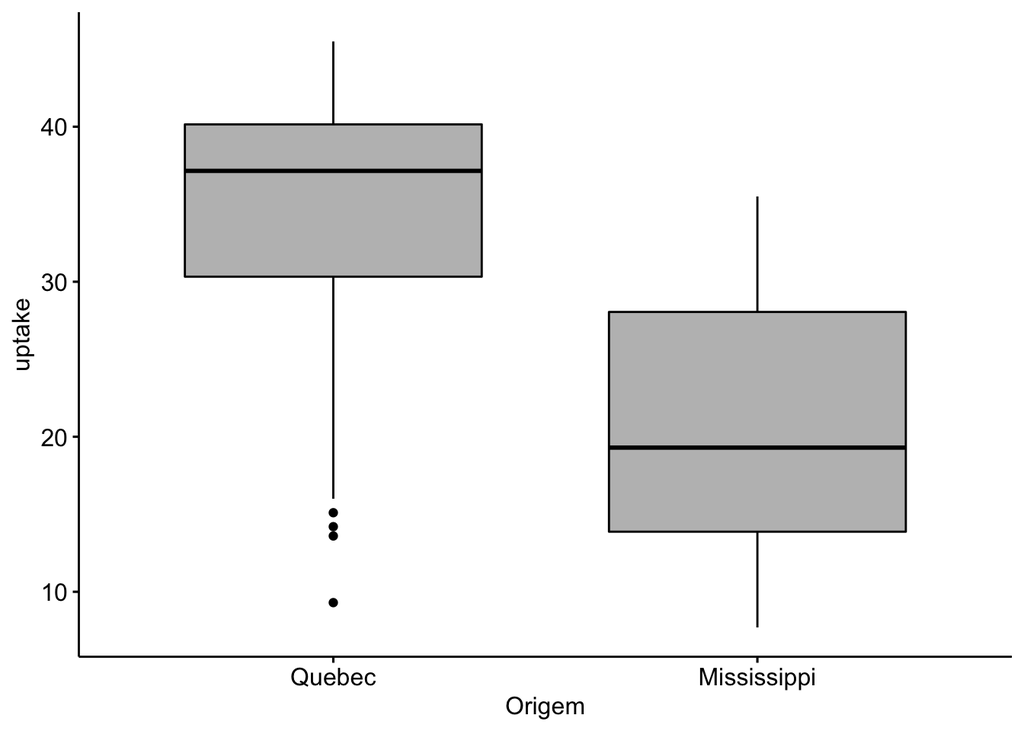

```r
ggboxplot(CO2, x = "Origem", y = "uptake", fill = "Gray"
          )
```

## 3.2 Orange.

```r
data(Orange)
glimpse(Orange)
```

```
## Rows: 35
## Columns: 3
## $ Tree          <ord> 1, 1, 1, 1, 1, 1, 1, 2, 2, 2, 2, 2, 2, 2, 3, 3, 3, 3, 3,…
## $ age           <dbl> 118, 484, 664, 1004, 1231, 1372, 1582, 118, 484, 664, 10…
## $ circumference <dbl> 30, 58, 87, 115, 120, 142, 145, 33, 69, 111, 156, 172, 2…
```

Aqui temos três variáveis. Árvore (Tree) queé uma variável ordinal, e Idade (age) e Circunferência (circumference) que são do tipo dublo (numéricas).

Aqui podemos pensar em uma regressão, tendo a Idade como variável explicativa e Circunferência como resposta.

| Árvore | Idade | Circunferência |
| --- | --- | --- |
| 1 | 118 | 30 |
| 1 | 484 | 58 |
| 1 | 664 | 87 |
| 1 | 1004 | 115 |
| 1 | 1231 | 120 |
| 1 | 1372 | 142 |
| 1 | 1582 | 145 |

### 3.2.1 Distribuição da variável Resposta

Histograma e Estatistica Descritiva

#### 3.2.1.1 Geral

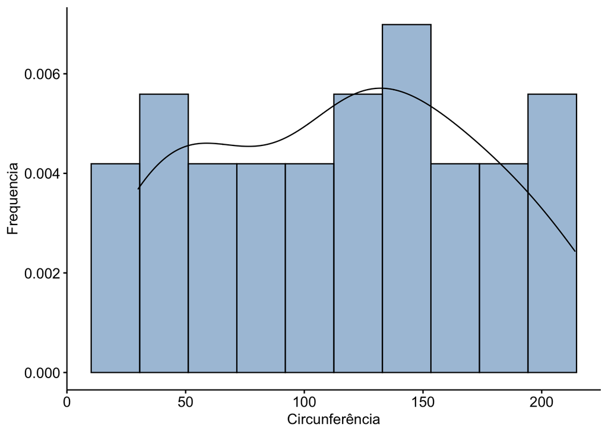

#### 3.2.1.2 Estatística Descritiva

| variable | n | min | max | median | iqr | mean | sd | se | ci |
| --- | --- | --- | --- | --- | --- | --- | --- | --- | --- |
| age | 35 | 118 | 1582 | 1004 | 888 | 922.143 | 491.865 | 83.140 | 168.961 |
| circumference | 35 | 30 | 214 | 115 | 96 | 115.857 | 57.488 | 9.717 | 19.748 |

Observamos pelo Histograma que a variável circunferência pode não possuir distribuição normal. Mas precisamos testar. Como faremos uma regressão, a homogeneidade e normalidade iremos testar sobre os resíduos.

### 3.2.2 Verificação dos pressupostos do modelo

Vamos primeiro criar o modelo para depois testar os pressupostos

```r
modelo <- lm (circumference ~ age, data = Orange)
```

#### 3.2.2.1 Normalidade

```r
normalidade_modelo<-shapiro.test(modelo$residuals)
```

|  | Estatistica | P |
| --- | --- | --- |
| W | 0.9728872 | 0.5273025 |

#### 3.2.2.2 Homogeneidade de Variâncias

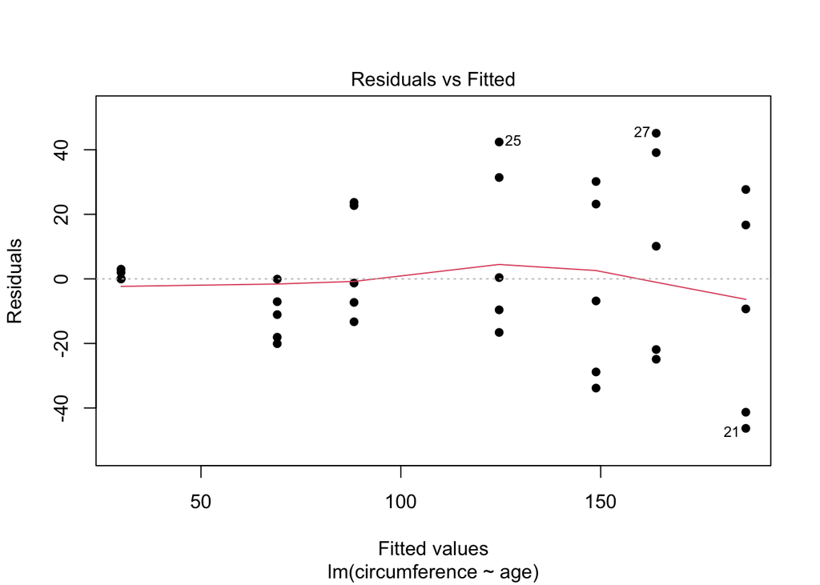

```r
# Usaremos o plot do modelo tendo os resíduos x os valores ajsutados. Queremos uma distribuição homogenea acima e abaixo da linha vermelha.

plot(modelo, which = 1, pch = 16)
```

Tanto a normalidade (P > 0.05), quando para a homogeneidade de variâncias (distribuição razoalvelmente homogenea) os pressupostos foram atendidos. Podemos seguir agora para avaliar se o parâmentro $\beta$<sub>1</sub> da idade é diferente de zero.

#### 3.2.2.3 Avaliando o Modelo

##### 3.2.2.3.1 Resultado do Teste

|  | Df | Sum Sq | Mean Sq | F value | Pr(>F) |
| --- | --- | --- | --- | --- | --- |
| age | 1 | 93771.54 | 93771.5413 | 166.4159 | 0 |
| Residuals | 33 | 18594.74 | 563.4771 | NA | NA |

##### 3.2.2.3.2 Parâmetros do Modelo

|  | Estimate | Std. Error | t value | Pr(>\|t\|) |
| --- | --- | --- | --- | --- |
| (Intercept) | 17.3996502 | 8.6226598 | 2.017898 | 0.0517927 |
| age | 0.1067703 | 0.0082766 | 12.900228 | 0.0000000 |

Na primera tabela temos o resultado da regressão no formato de uma tabela de ANOVA, na segunda temos os parâmetros para a equação da reta. Assim, temos regressão da idade sobre a circunferência, onde a medida que a laranjeira envelhece sua circunferência aumenta [F(1,33) = 166.4159; P < 0.01]. A equação da reta fica assim,

$$\operatorname{y} = 17.4 + 0.106(\operatorname{x}) + \epsilon$$

#### 3.2.2.4 O Gráfico final para a regressão.

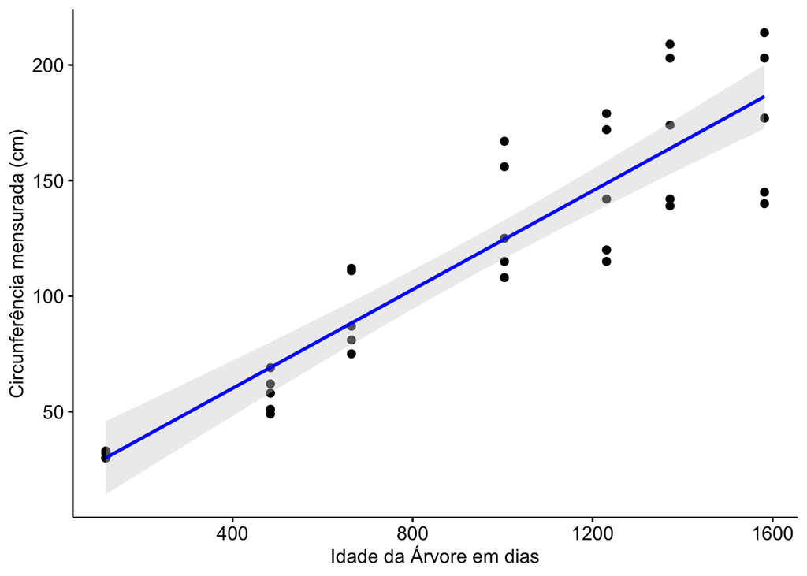

```r
ggscatter(Orange,
          x = "age",
          y = "circumference",
          add = "reg.line",
          conf.int = TRUE,
          add.params = list(color = "blue",
                            fill = "lightgray"),
          xlab = "Idade da Árvore em dias",
          ylab = "Circunferência mensurada (cm)")
```

## 3.3 ChickWeight.

```r
data(ChickWeight)
glimpse(ChickWeight)
```

```
## Rows: 578
## Columns: 4
## $ weight <dbl> 42, 51, 59, 64, 76, 93, 106, 125, 149, 171, 199, 205, 40, 49, 5…
## $ Time   <dbl> 0, 2, 4, 6, 8, 10, 12, 14, 16, 18, 20, 21, 0, 2, 4, 6, 8, 10, 1…
## $ Chick  <ord> 1, 1, 1, 1, 1, 1, 1, 1, 1, 1, 1, 1, 2, 2, 2, 2, 2, 2, 2, 2, 2, …
## $ Diet   <fct> 1, 1, 1, 1, 1, 1, 1, 1, 1, 1, 1, 1, 1, 1, 1, 1, 1, 1, 1, 1, 1, …
```

Aqui temos quatro variáveis, sendo Peso (weight), Tempo (Time) como sendo variáveis do tipo duplo (numéricas), Frango (Chick) como Ordinal e por fim a Dieta oferencida (Diet).

Aqui primerio criarei um gráfico com os dados para ver quais caminhos podemos seguir.

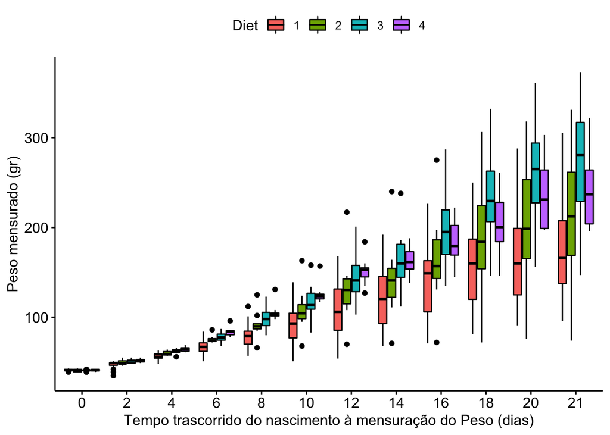

```r
ggboxplot(ChickWeight,
          x = "Time",
          y = "weight",
          fill = "Diet",
          xlab = "Tempo trascorrido do nascimento à mensuração do Peso (dias)",
          ylab = "Peso mensurado (gr)")
```

Veja que temos o tempo como uma informação importante, ainda temos os indivíduos, e aqui ainda que todos os frangos tenham sido mensurados no mesmo tempo, eles não receberam o mesmo tratamento. Isso seria um modelo misto ou aninhado. Pois temos dieta como fator de estudo, dentro desse fator temos o tempo, e os indivíduos como as unidades amostrais.

Aqui não temos um valor de corte para o abate, pelo menos não tremos essa informação no conjunto de dados. Podemos simplificar nossa análise e pegar somente os valores de peso e dieta para quando o tempo = 21. Assim, Teremos uma ANOVA de um fator. não quero saber como o tempo influenciou o experimento, quero o resultado final que é aos 21 dias.

Logo vamos dividir o conjunto com base em `time == "21"`.

```r
# Irei criar um novo conjunto de dados

df <- ChickWeight |>
  convert_as_factor(Time) |>
  filter(Time == "21") # Usando filter == "21", pegaremos somente os dados para         quando o tempo for igual a 21.
```

| Peso | Tempo | Frango | Dieta |
| --- | --- | --- | --- |
| 205 | 21 | 1 | 1 |
| 215 | 21 | 2 | 1 |
| 202 | 21 | 3 | 1 |
| 157 | 21 | 4 | 1 |
| 223 | 21 | 5 | 1 |
| 157 | 21 | 6 | 1 |
| 305 | 21 | 7 | 1 |
| 98 | 21 | 9 | 1 |
| 124 | 21 | 10 | 1 |
| 175 | 21 | 11 | 1 |

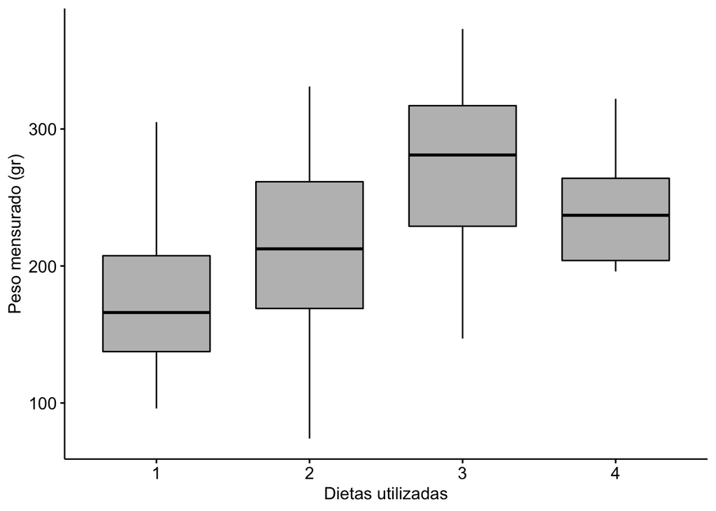

```r
ggboxplot(df,
          x = "Diet",
          y = "weight",
          fill = "gray",
          xlab = "Dietas utilizadas",
          ylab = "Peso mensurado (gr)")
```

Agora podemos realizar uma ANOVA de um fator, sem se preocupar com a influencia do tempo sobre os resultado.

### 3.3.1 Distribuição da variável Resposta

Histograma e Estatistica Descritiva

#### 3.3.1.1 Geral

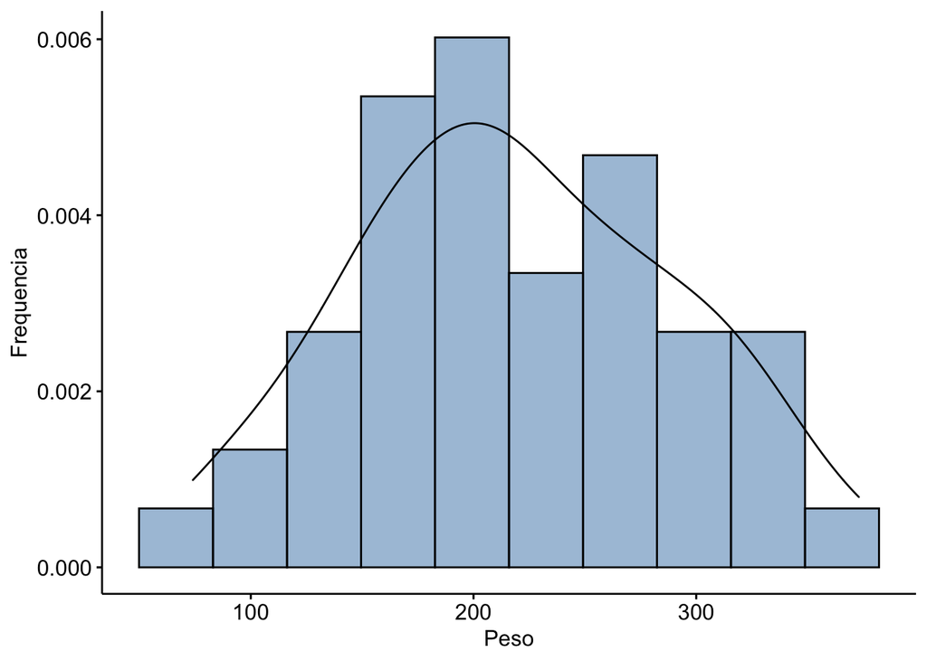

#### 3.3.1.2 Estatística Descritiva

| Diet | variable | n | min | max | median | iqr | mean | sd | se | ci |
| --- | --- | --- | --- | --- | --- | --- | --- | --- | --- | --- |
| 1 | weight | 16 | 96 | 305 | 166.0 | 70.0 | 177.750 | 58.702 | 14.676 | 31.280 |
| 2 | weight | 10 | 74 | 331 | 212.5 | 92.5 | 214.700 | 78.138 | 24.709 | 55.897 |
| 3 | weight | 10 | 147 | 373 | 281.0 | 88.0 | 270.300 | 71.623 | 22.649 | 51.236 |
| 4 | weight | 9 | 196 | 322 | 237.0 | 60.0 | 238.556 | 43.348 | 14.449 | 33.320 |

### 3.3.2 Verificação dos pressupostos do modelo

#### 3.3.2.1 Normalidade

A variável dependente Peso (Weight) deve apresentar distribuição aproximadamente normal dentro de cada nível da variável Dieta (Diet). A normalidade será avaliada pelo teste de Shapiro-Wilk.

```r
shapiro.df <- df %>% group_by(Diet) %>% shapiro_test(weight)
```

| Diet | variable | statistic | p |
| --- | --- | --- | --- |
| 1 | weight | 0.9560199 | 0.5905451 |
| 2 | weight | 0.9772523 | 0.9487857 |
| 3 | weight | 0.9704507 | 0.8949919 |
| 4 | weight | 0.8869371 | 0.1855202 |

Observamos que os valores de P foram maiores que 0.05. Logo a variáel Peso (weight) possui distribuição normal.

#### 3.3.2.2 Homogeneidade de variâncias

A variável dependente Peso (Weight) deve apresentar variâncias iguais em caga nível da da variável Dieta (Diet). A normalidade será avaliada pelo teste de Levene.

```r
levene.df <- df %>% levene_test(weight~Diet)
```

| df1 | df2 | statistic | p |
| --- | --- | --- | --- |
| 3 | 41 | 1.159719 | 0.3367392 |

Há homogenidade de variâncias entre os níveis de Dieta (Diet).

### 3.3.3 Ambos os pressupostos foram antendidos, agora podemos realizar a ANOVA de um Fator.

```r
modelo.df <- aov(weight~Diet, data = df)
```

|  | Df | Sum Sq | Mean Sq | F value | Pr(>F) |
| --- | --- | --- | --- | --- | --- |
| Diet | 3 | 57164.22 | 19054.741 | 4.654713 | 0.006858 |
| Residuals | 41 | 167839.42 | 4093.644 | NA | NA |

O gráfico final fica assim…

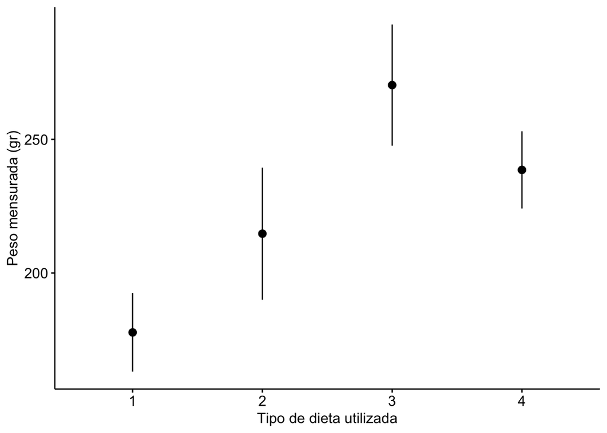

#### 3.3.3.1 *Pos Hoc*

Agora que a ANOVA foi significativa [F(3,41) = 4.65, P = 0.006], ou seja há efeito da dieta sobre o ganho de peso. Precisamos agora saber onde essa diferneça está. Usaremos o teste de Tukey para avaliar as diferenças entre os grupos.

```r
resu.tukey <- TukeyHSD(modelo.df)
```

[output not shown]

# 4 Uma última Palavra

Esse exercício é uma amostra de como os dados podem ser analisados. É importante ter em mente que o conhecimento teórico sobre desenho experimental, sobre o que é um fator de estudo, qual a variável que efetivamente responde nossas perguntas (*objetivo*/*hipóteses*) é de suma importância. Pois e desse conhecimento que o melhor teste e ou modelo poderá ser realizado ou construido.

```
                            This is the End... dan dan dan
```